# 205.2. PSF for visits

For the Rubin Science Platform at data.lsst.cloud.  
Data Release: [Data Preview 2](https://dp2.lsst.io/)  
Container Size: Large  
LSST Science Pipelines version: r30.0.10  
Last verified to run: 2026-07-22  
Repository: github.com/lsst/tutorial-notebooks  
DOI: 10.11578/rubin/dc.20250909.20

**Learning objective:** To understand and characterize the Point Spread Function (PSF) model of a single visit in DP2.

**LSST data products:** `visit_summary`

**Packages:** `lsst.daf.butler`, `lsst.afw.display`, `lsst.images`, `numpy`, `matplotlib`, `scipy`, `galsim`.

**Credit:** Originally developed by the Rubin Community Science team. Section 3.2 on PSF size and shape uses the GalSim HSM interface. Please consider acknowledging them if this notebook is used for the preparation of journal articles, software releases, or other notebooks.

**Get Support:** Everyone is encouraged to ask questions or raise issues in the [Support Category](https://community.lsst.org/c/support) of the Rubin Community Forum. Rubin staff will respond to all questions posted there.

## 1. Introduction

This notebook demonstrates how to obtain the PSF model of a single visit in DP2, and how to characterize its size, shape, and profile.

In DP2 the per-detector PSF model for a visit is stored in the `visit_summary` table (a legacy `lsst.afw.detection.Psf`, modeled with the ["PSF in the Full Field of View"](https://ui.adsabs.harvard.edu/abs/2021ascl.soft02024J/abstract) (PIFF) software). This notebook retrieves that legacy PSF and wraps it into the new `lsst.images` `PointSpreadFunction` with the `from_legacy` method, so that it can be used through the same interface as the `deep_coadd` PSF (see the DP2 tutorial on the PSF in coadded images, and the astrometric calibration tutorial, which wraps the visit WCS the same way).

The new PSF object provides `compute_kernel_image` and `compute_stellar_image` methods. It does not provide the shape, second-moment, aperture-flux, or peak methods of the DP1 `afw` PSF; the PSF size and shape are measured here instead with the GalSim HSM adaptive moments (Section 3.2).

> **Note:** Early DP2 (EDP2) does not include the `visit_image` pixel data, so this notebook works with the PSF *model* only. A comparison of the model against observed stars (PSF residuals) requires the visit-image pixels and is deferred to a future update.

**Related tutorials:** See the DP2 tutorials on the PSF in `deep_coadd` images and on astrometric calibration.

### 1.1. Import packages

Import `numpy`, a fundamental package for scientific computing with arrays in Python (numpy.org), and `matplotlib`, a comprehensive library for data visualization ([matplotlib.org](https://matplotlib.org/)).

From `scipy`, import tools for numerical optimization and statistics ([scipy.org](https://scipy.org/)).

Import `galsim`, the modular galaxy image simulation toolkit, for its HSM adaptive-moments interface (github.com/GalSim-developers/GalSim).

From the LSST Science Pipelines, import display utilities, the Butler, and the new `lsst.images` PSF interface ([pipelines.lsst.io](https://pipelines.lsst.io/)).

```python
import matplotlib.pyplot as plt
import numpy as np
from scipy.optimize import curve_fit
from scipy.stats import skew
import galsim
import lsst.afw.display as afwDisplay
from lsst.daf.butler import Butler
from lsst.images import Box
from lsst.images.psfs import PointSpreadFunction
```

### 1.2. Define parameters and functions

**Constant**: `SIGMA_TO_FWHM`

The conversion factor between the standard deviation `sigma` of a Gaussian function and the full-width at half-maximum (FWHM): $2\sqrt{2\ln(2)}$.

```python
SIGMA_TO_FWHM = 2.0*np.sqrt(2.0*np.log(2.0))
```

**Function**: `gauss`

A one-dimensional Gaussian profile.

```python
def gauss(x, a, x0, sigma):
    """Evaluate a 1D Gaussian function.

    Parameters
    ----------
    x : `array_like`
        Input values where the Gaussian is evaluated.
    a : `float`
        Amplitude of the Gaussian peak.
    x0 : `float`
        Mean (center) of the Gaussian.
    sigma : `float`
        Standard deviation (width) of the Gaussian.

    Returns
    -------
    y : `array_like`
        Values of the Gaussian evaluated at `x`.
    """
    return a * np.exp(-(x - x0)**2 / (2 * sigma**2))
```

Set `afwDisplay` to use `firefly` for image display.

```python
afwDisplay.setDefaultBackend('firefly')
afw_display = afwDisplay.Display(frame=1)
```

Instantiate the Butler with the DP2 repository and collection.

```python
butler = Butler("dp2", collections="dp2")
```

## 2. Retrieve the visit PSF model

Use a location near the center of the Extended Chandra Deep Field South (ECDFS), in degrees, and the *r* band.

```python
ra_cen, dec_cen = 53.076, -28.110
my_band = 'r'
```

Find a visit and detector whose footprint overlaps the target position, using the `visit_detector_region` dimension records (registry metadata only; no image is read).

```python
detector_records = butler.query_dimension_records(
    "visit_detector_region",
    where="band.name = :band AND visit_detector_region.region OVERLAPS POINT(:ra, :dec)",
    bind={"band": my_band, "ra": ra_cen, "dec": dec_cen})
visit_id = detector_records[0].dataId["visit"]
detector_id = detector_records[0].dataId["detector"]
print("Using visit:", visit_id, "| detector:", detector_id)
```

```
Using visit: 2025072200466 | detector: 94
```

Get the `visit_summary` for this visit, and retrieve the legacy PSF and bounding box for the chosen detector.

```python
visit_summary = butler.get("visit_summary", instrument="LSSTCam", visit=visit_id)
record = visit_summary.find(detector_id)
legacy_psf = record.getPsf()
detector_bbox = Box.from_legacy(record.getBBox())
```

Wrap the legacy `afw` PSF into an `lsst.images` `PointSpreadFunction` with `from_legacy`, passing the detector bounding box as the region where the model is valid. The factory automatically selects the appropriate wrapper for the Piff PSF.

```python
psf = PointSpreadFunction.from_legacy(legacy_psf, bounds=detector_bbox)
```

> **Note:** The PSF is obtained here from `visit_summary`. Once the full DP2 release is available, the visit PSF will also be accessible directly as `visit_image.psf` (the same component-based access used for `deep_coadd.psf`), which will be the preferred method; the `visit_summary` approach shown here is used in the interim.

Define a pixel position within the detector at which to evaluate the PSF model.

```python
x_pix, y_pix = 2000.0, 2000.0
```

Use the `compute_kernel_image` method to evaluate the PSF at the chosen point. This returns an `lsst.images.Image` centered on the origin (0, 0), suitable for convolution.

```python
psf_kernel_image = psf.compute_kernel_image(x=x_pix, y=y_pix)

afw_display = afwDisplay.Display(frame=1)
afw_display.scale('asinh', 'zscale')
afw_display.mtv(psf_kernel_image)
```

> **Figure 1:** PSF model from the `compute_kernel_image` method, centered on the origin.

Use the `compute_stellar_image` method. This evaluates the PSF centered on the given coordinates, just like the postage stamp of a star would appear.

```python
psf_stellar_image = psf.compute_stellar_image(x=x_pix, y=y_pix)

afw_display = afwDisplay.Display(frame=2)
afw_display.scale('asinh', 'zscale')
afw_display.mtv(psf_stellar_image)
```

> **Figure 2:** PSF model from the `compute_stellar_image` method, centered on the star position.

The `compute_stellar_bbox` method returns the bounding box of the image that `compute_stellar_image` would produce at a given position, without computing the image itself.

```python
stellar_bbox = psf.compute_stellar_bbox(x=x_pix, y=y_pix)
stellar_bbox
```

```
Box(y=Interval(start=1987, stop=2014), x=Interval(start=1987, stop=2014))
```

## 3. PSF size and shape

The new visit PSF (a `PointSpreadFunction`) does not provide the shape, second-moment, aperture-flux, or peak methods of the DP1 `afw` PSF. This tutorial measures the PSF size and shape with the GalSim HSM adaptive moments (Section 3.2); the postage-stamp dimensions are read directly from the PSF image array (Section 3.1).

### 3.1. Postage stamp dimensions

Get the PSF postage stamp dimensions, in pixels, from the kernel image array.

```python
psf_image_array = psf_kernel_image.array
ylen, xlen = psf_image_array.shape
print(f"PSF postage stamp dimensions: {xlen} x {ylen} pix")
```

```
PSF postage stamp dimensions: 27 x 27 pix
```

### 3.2. PSF size and shape with GalSim HSM

An independent way to characterize the PSF size and shape is with adaptive moments, using the HSM algorithm ([Hirata & Seljak 2003](https://ui.adsabs.harvard.edu/abs/2003MNRAS.343..459H/abstract); [Mandelbaum et al. 2005](https://ui.adsabs.harvard.edu/abs/2005MNRAS.361.1287M/abstract)) as implemented in GalSim. `galsim.hsm.FindAdaptiveMom` fits an elliptical Gaussian to the image and returns the adaptive-moments size `moments_sigma` (the determinant radius $|\det M|^{1/4}$, in pixels) and the `observed_shape` (a `Shear` with ellipticity components `e1` and `e2`).

Wrap the PSF kernel image array in a `galsim.Image` with a pixel scale of 1 (so the size is measured in pixels), and run the adaptive-moments measurement.

```python
gs_image = galsim.Image(np.ascontiguousarray(psf_kernel_image.array), scale=1.0)
hsm_result = galsim.hsm.FindAdaptiveMom(gs_image, guess_sig=3.0)
```

Report the HSM size, full-width at half maximum, and ellipticity.

```python
hsm_sigma = hsm_result.moments_sigma
hsm_fwhm = hsm_sigma * SIGMA_TO_FWHM
shape = hsm_result.observed_shape
print(f"HSM size (moments_sigma): {hsm_sigma: .3f} pix")
print(f"HSM FWHM: {hsm_fwhm: .3f} pix")
print(f"HSM ellipticity: e1 = {shape.e1: .4f}, e2 = {shape.e2: .4f}, |e| = {shape.e: .4f}")
```

```
HSM size (moments_sigma):  4.480 pix
HSM FWHM:  10.550 pix
HSM ellipticity: e1 =  0.0248, e2 =  0.0604, |e| =  0.0653
```

## 4. PSF radial profile

Compute the center of the PSF image from its dimensions.

```python
center_pix = np.array([xlen / 2, ylen / 2])
```

Create a coordinate grid and calculate the distance from each pixel to the center.

```python
yy, xx = np.indices((ylen, xlen))
coords = np.stack((xx, yy), axis=-1)
distances = np.linalg.norm(coords - center_pix, axis=-1)
```

Apply a radial mask.

```python
mask = distances <= xlen / 2
values = psf_image_array[mask]
dists = distances[mask]
```

Set initial parameters and bounds for a Gaussian fit of the radial profile.

```python
p0 = [np.max(values), 0, 10]
bounds = ((0, 0, 0), (np.inf, np.inf, np.inf))
```

Fit a Gaussian profile.

```python
try:
    pars, _ = curve_fit(gauss, dists, values, p0=p0, bounds=bounds)
    pars[0] = np.abs(pars[0])
    pars[2] = np.abs(pars[2])
except RuntimeError:
    pars = None
```

Plot the radial profile.

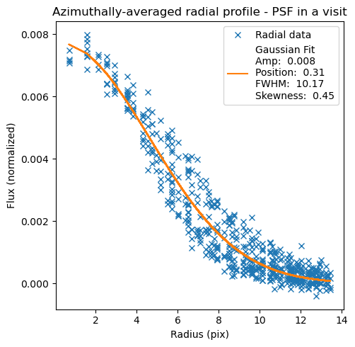

```python
fig, ax = plt.subplots(figsize=(6, 5))
ax.plot(dists, values, 'x', label='Radial data')

if pars is not None:
    fitAmp, fitMean, fitSigma = pars
    fitFwhm = fitSigma * SIGMA_TO_FWHM
    x_fit = np.linspace(-np.max(dists), np.max(dists), 200)
    skewness_val = skew(gauss(x_fit, *pars))
    ax.plot(dists, gauss(dists, *pars), label=(
        f"Gaussian Fit\n"
        f"Amp: {fitAmp: .3f}\n"
        f"Position: {fitMean: .2f}\n"
        f"FWHM: {fitFwhm: .2f}\n"
        f"Skewness: {skewness_val: .2f}"))

ax.set_xlabel("Radius (pix)")
ax.set_ylabel("Flux (normalized)")
ax.set_title("Azimuthally-averaged radial profile - PSF in a visit")
ax.set_aspect(1.0 / ax.get_data_ratio(), adjustable='box')
ax.legend()
plt.tight_layout()
plt.show()
```

> **Figure 3:** Azimuthally-averaged PSF radial profile, fitted with a Gaussian function.

## 5. PSF curve of growth (encircled energy)

Sort the distances calculated above.

```python
sorted_indices = np.argsort(dists)
dists_sorted = dists[sorted_indices]
values_sorted = values[sorted_indices]
```

Compute the normalized cumulative flux.

```python
cum_fluxes = np.cumsum(values_sorted)
cum_fluxes_norm = cum_fluxes / np.max(cum_fluxes)
```

Plot the curve of growth.

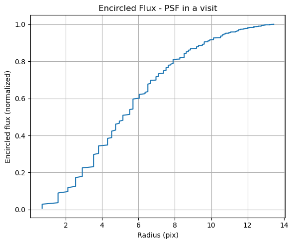

```python
fig, ax = plt.subplots(figsize=(6, 5))
ax.plot(dists_sorted, cum_fluxes_norm, markersize=10)
ax.set_ylabel('Encircled flux (normalized)')
ax.set_xlabel('Radius (pix)')
ax.set_title("Encircled Flux - PSF in a visit")
ax.grid(True)
plt.tight_layout()
plt.show()
```

> **Figure 4:** PSF curve of growth.

## 6. Make a 2D PSF contour plot

Define intensity percentiles for the contour levels.

```python
vmin = np.percentile(psf_image_array, 0.1)
vmax = np.percentile(psf_image_array, 99.9)
nContours = 10
lvls = np.linspace(vmin, vmax, nContours)
```

Define a coordinate grid centered around (0, 0).

```python
xg, yg = np.meshgrid(np.linspace(-xlen / 2, xlen / 2, xlen),
                     np.linspace(-ylen / 2, ylen / 2, ylen))
```

Plot the contours.

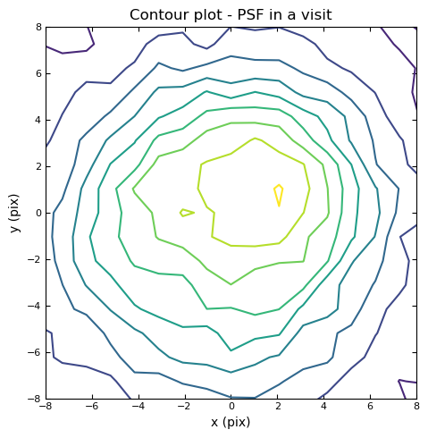

```python
fig, ax = plt.subplots(figsize=(6, 5))
ax.contour(xg, yg, psf_image_array, levels=lvls)
ax.tick_params(which="both", direction="in", top=True, right=True, labelsize=8)
ax.set_aspect("equal")
ax.set_xlabel('x (pix)')
ax.set_ylabel('y (pix)')
ax.set_title("Contour plot - PSF in a visit")
ax.set_xlim([-8, 8])
ax.set_ylim([-8, 8])
plt.tight_layout()
plt.show()
```

> **Figure 5:** PSF contour plot.